# Setup and Context

### Introduction

On November 27, 1895, Alfred Nobel signed his last will in Paris. When it was opened after his death, the will caused a lot of controversy, as Nobel had left much of his wealth for the establishment of a prize.

Alfred Nobel dictates that his entire remaining estate should be used to endow “prizes to those who, during the preceding year, have conferred the greatest benefit to humankind”.

Every year the Nobel Prize is given to scientists and scholars in the categories chemistry, literature, physics, physiology or medicine, economics, and peace.

[figure not shown]

Let's see what patterns we can find in the data of the past Nobel laureates. What can we learn about the Nobel prize and our world more generally?

### Import Statements

```python
import pandas as pd
import numpy as np
import plotly.express as px
import plotly.offline as pyo
import seaborn as sns
import matplotlib.pyplot as plt
from fractions import Fraction

pyo.init_notebook_mode(connected=True)
```

### Notebook Presentation

```python
pd.options.display.float_format = '{:,.2f}'.format
```

### Read the Data

```python
df_data = pd.read_csv('nobel_prize_data.csv')
df_data.head()
```

|  | year | category | prize | motivation | prize_share | laureate_type | full_name | birth_date | birth_city | birth_country | birth_country_current | sex | organization_name | organization_city | organization_country | ISO |
| --- | --- | --- | --- | --- | --- | --- | --- | --- | --- | --- | --- | --- | --- | --- | --- | --- |
| 0 | 1901 | Chemistry | The Nobel Prize in Chemistry 1901 | "in recognition of the extraordinary services ... | 1/1 | Individual | Jacobus Henricus van 't Hoff | 1852-08-30 | Rotterdam | Netherlands | Netherlands | Male | Berlin University | Berlin | Germany | NLD |
| 1 | 1901 | Literature | The Nobel Prize in Literature 1901 | "in special recognition of his poetic composit... | 1/1 | Individual | Sully Prudhomme | 1839-03-16 | Paris | France | France | Male | NaN | NaN | NaN | FRA |
| 2 | 1901 | Medicine | The Nobel Prize in Physiology or Medicine 1901 | "for his work on serum therapy, especially its... | 1/1 | Individual | Emil Adolf von Behring | 1854-03-15 | Hansdorf (Lawice) | Prussia (Poland) | Poland | Male | Marburg University | Marburg | Germany | POL |
| 3 | 1901 | Peace | The Nobel Peace Prize 1901 | NaN | 1/2 | Individual | Frédéric Passy | 1822-05-20 | Paris | France | France | Male | NaN | NaN | NaN | FRA |
| 4 | 1901 | Peace | The Nobel Peace Prize 1901 | NaN | 1/2 | Individual | Jean Henry Dunant | 1828-05-08 | Geneva | Switzerland | Switzerland | Male | NaN | NaN | NaN | CHE |

Caveats: The exact birth dates for Michael Houghton, Venkatraman Ramakrishnan, and Nadia Murad are unknown. I've substituted them with mid-year estimate of July 2nd.

# Data Exploration & Cleaning

**Challenge**: Preliminary data exploration.

- What is the shape of `df_data`? How many rows and columns?
- What are the column names?
- In which year was the Nobel prize first awarded?
- Which year is the latest year included in the dataset?

```python
df_data.info()
```

```
<class 'pandas.core.frame.DataFrame'>
RangeIndex: 962 entries, 0 to 961
Data columns (total 16 columns):
 #   Column                 Non-Null Count  Dtype
---  ------                 --------------  -----
 0   year                   962 non-null    int64
 1   category               962 non-null    object
 2   prize                  962 non-null    object
 3   motivation             874 non-null    object
 4   prize_share            962 non-null    object
 5   laureate_type          962 non-null    object
 6   full_name              962 non-null    object
 7   birth_date             934 non-null    object
 8   birth_city             931 non-null    object
 9   birth_country          934 non-null    object
 10  birth_country_current  934 non-null    object
 11  sex                    934 non-null    object
 12  organization_name      707 non-null    object
 13  organization_city      707 non-null    object
 14  organization_country   708 non-null    object
 15  ISO                    934 non-null    object
dtypes: int64(1), object(15)
memory usage: 120.4+ KB
```

```python
df_data.describe()
```

|  | year |
| --- | --- |
| count | 962.00 |
| mean | 1,971.82 |
| std | 33.81 |
| min | 1,901.00 |
| 25% | 1,948.00 |
| 50% | 1,977.00 |
| 75% | 2,001.00 |
| max | 2,020.00 |

**Challange**:

- Are there any duplicate values in the dataset?
- Are there NaN values in the dataset?
- Which columns tend to have NaN values?
- How many NaN values are there per column?
- Why do these columns have NaN values?

### Check for Duplicates

```python
print(df_data.duplicated().sum())
```

```
0
```

### Check for NaN Values

```python
print(df_data.isna().sum())
```

```
year                       0
category                   0
prize                      0
motivation                88
prize_share                0
laureate_type              0
full_name                  0
birth_date                28
birth_city                31
birth_country             28
birth_country_current     28
sex                       28
organization_name        255
organization_city        255
organization_country     254
ISO                       28
dtype: int64
```

### Type Conversions

**Challenge**:

- Convert the `birth_date` column to Pandas `Datetime` objects
- Add a Column called `share_pct` which has the laureates' share as a percentage in the form of a floating-point number.

#### Convert Year and Birth Date to Datetime

```python
df_data['birth_date'] = pd.to_datetime(df_data['birth_date'])
df_data.info()
```

```
<class 'pandas.core.frame.DataFrame'>
RangeIndex: 962 entries, 0 to 961
Data columns (total 16 columns):
 #   Column                 Non-Null Count  Dtype
---  ------                 --------------  -----
 0   year                   962 non-null    int64
 1   category               962 non-null    object
 2   prize                  962 non-null    object
 3   motivation             874 non-null    object
 4   prize_share            962 non-null    object
 5   laureate_type          962 non-null    object
 6   full_name              962 non-null    object
 7   birth_date             934 non-null    datetime64[ns]
 8   birth_city             931 non-null    object
 9   birth_country          934 non-null    object
 10  birth_country_current  934 non-null    object
 11  sex                    934 non-null    object
 12  organization_name      707 non-null    object
 13  organization_city      707 non-null    object
 14  organization_country   708 non-null    object
 15  ISO                    934 non-null    object
dtypes: datetime64[ns](1), int64(1), object(14)
memory usage: 120.4+ KB
```

#### Add a Column with the Prize Share as a Percentage

```python
df_data['prize_share'] = df_data['prize_share'].apply(lambda x: float(Fraction(x)))
```

```python
df_data.info()
```

```
<class 'pandas.core.frame.DataFrame'>
RangeIndex: 962 entries, 0 to 961
Data columns (total 16 columns):
 #   Column                 Non-Null Count  Dtype
---  ------                 --------------  -----
 0   year                   962 non-null    int64
 1   category               962 non-null    object
 2   prize                  962 non-null    object
 3   motivation             874 non-null    object
 4   prize_share            962 non-null    float64
 5   laureate_type          962 non-null    object
 6   full_name              962 non-null    object
 7   birth_date             934 non-null    datetime64[ns]
 8   birth_city             931 non-null    object
 9   birth_country          934 non-null    object
 10  birth_country_current  934 non-null    object
 11  sex                    934 non-null    object
 12  organization_name      707 non-null    object
 13  organization_city      707 non-null    object
 14  organization_country   708 non-null    object
 15  ISO                    934 non-null    object
dtypes: datetime64[ns](1), float64(1), int64(1), object(13)
memory usage: 120.4+ KB
```

# Ask 3 questions

```python
by_county = df_data.groupby(by='birth_country_current').size().sort_values(ascending=False).head(10)
fig = px.pie(by_county, values=by_county.values, names=by_county.index, title='Top 10 Counties')
fig.update_traces(textposition='inside', textinfo='percent')
fig.show()
```

[interactive chart not shown]

```python
by_category = df_data.groupby(by='category').size().sort_values()
fig = px.bar(by_category, x=by_category.index, y=by_category.values, color=by_category.index)
fig.show()
```

[interactive chart not shown]

```python
by_type = df_data.groupby(by='laureate_type').size()
fig = px.pie(by_type, values=by_type.values, names=by_type.index, title='Noble pize by Type')
fig.update_traces(textposition='outside', textinfo='percent')
fig.show()
```

[interactive chart not shown]

# Plotly Donut Chart: Percentage of Male vs. Female Laureates

**Challenge**: Create a [donut chart using plotly](https://plotly.com/python/pie-charts/) which shows how many prizes went to men compared to how many prizes went to women. What percentage of all the prizes went to women?

```python
by_sex = df_data.groupby(by='sex').size()
fig = px.pie(by_sex, values=by_sex.values, names=by_sex.index,
            title='Noble pize by Sex', hole=0.4)
fig.update_traces(textposition='inside', textinfo='percent')
fig.show()
```

[interactive chart not shown]

# Who were the first 3 Women to Win the Nobel Prize?

**Challenge**:

- What are the names of the first 3 female Nobel laureates?
- What did the win the prize for?
- What do you see in their `birth_country`? Were they part of an organisation?

```python
top_women = df_data[df_data['sex'] == 'Female'].sort_values(by=['year']).head(3)
top_women
```

|  | year | category | prize | motivation | prize_share | laureate_type | full_name | birth_date | birth_city | birth_country | birth_country_current | sex | organization_name | organization_city | organization_country | ISO |
| --- | --- | --- | --- | --- | --- | --- | --- | --- | --- | --- | --- | --- | --- | --- | --- | --- |
| 18 | 1903 | Physics | The Nobel Prize in Physics 1903 | "in recognition of the extraordinary services ... | 0.25 | Individual | Marie Curie, née Sklodowska | 1867-11-07 | Warsaw | Russian Empire (Poland) | Poland | Female | NaN | NaN | NaN | POL |
| 29 | 1905 | Peace | The Nobel Peace Prize 1905 | NaN | 1.00 | Individual | Baroness Bertha Sophie Felicita von Suttner, n... | 1843-06-09 | Prague | Austrian Empire (Czech Republic) | Czech Republic | Female | NaN | NaN | NaN | CZE |
| 51 | 1909 | Literature | The Nobel Prize in Literature 1909 | "in appreciation of the lofty idealism, vivid ... | 1.00 | Individual | Selma Ottilia Lovisa Lagerlöf | 1858-11-20 | Mårbacka | Sweden | Sweden | Female | NaN | NaN | NaN | SWE |

# Find the Repeat Winners

**Challenge**: Did some people get a Nobel Prize more than once? If so, who were they?

```python
multi_winner = list(df_data[df_data.duplicated(subset=['full_name'])]['full_name'])
for winner in multi_winner:
    print(winner)
```

```
Marie Curie, née Sklodowska
Comité international de la Croix Rouge (International Committee of the Red Cross)
Linus Carl Pauling
Comité international de la Croix Rouge (International Committee of the Red Cross)
John Bardeen
Frederick Sanger
Office of the United Nations High Commissioner for Refugees (UNHCR)
```

# Number of Prizes per Category

**Challenge**:

- In how many categories are prizes awarded?
- Create a plotly bar chart with the number of prizes awarded by category.
- Use the color scale called `Aggrnyl` to colour the chart, but don't show a color axis.
- Which category has the most number of prizes awarded?
- Which category has the fewest number of prizes awarded?

```python
by_category = df_data.groupby(by='category').size().sort_values()
fig = px.bar(by_category, x=by_category.index, y=by_category.values,
            color=by_category.values, color_continuous_scale=px.colors.sequential.Aggrnyl)

fig.update(layout_coloraxis_showscale=False)
fig.show()
```

[interactive chart not shown]

**Challenge**:

- When was the first prize in the field of Economics awarded?
- Who did the prize go to?

```python
first_eco = df_data[df_data['category'] == 'Economics'].sort_values(by='year')
first_eco = first_eco[first_eco['year'] == first_eco['year'].min()]
first_eco
```

|  | year | category | prize | motivation | prize_share | laureate_type | full_name | birth_date | birth_city | birth_country | birth_country_current | sex | organization_name | organization_city | organization_country | ISO |
| --- | --- | --- | --- | --- | --- | --- | --- | --- | --- | --- | --- | --- | --- | --- | --- | --- |
| 393 | 1969 | Economics | The Sveriges Riksbank Prize in Economic Scienc... | "for having developed and applied dynamic mode... | 0.50 | Individual | Jan Tinbergen | 1903-04-12 | the Hague | Netherlands | Netherlands | Male | The Netherlands School of Economics | Rotterdam | Netherlands | NLD |
| 394 | 1969 | Economics | The Sveriges Riksbank Prize in Economic Scienc... | "for having developed and applied dynamic mode... | 0.50 | Individual | Ragnar Frisch | 1895-03-03 | Oslo | Norway | Norway | Male | University of Oslo | Oslo | Norway | NOR |

```python
print(f'The first prize for Economics was awarded in {first_eco.year.values[0]}')
```

```
The first prize for Economics was awarded in 1969
```

```python
print(f'This prize went to {first_eco["full_name"].values}')
```

```
This prize went to ['Jan Tinbergen' 'Ragnar Frisch']
```

# Male and Female Winners by Category

**Challenge**: Create a [plotly bar chart](https://plotly.com/python/bar-charts/) that shows the split between men and women by category.

- Hover over the bar chart. How many prizes went to women in Literature compared to Physics?

```python
category_sex = df_data.groupby(by=['category', 'sex']).size().unstack()
category_sex.sort_values(by=['Male'], inplace=True, ascending=False)
```

```python
fig = px.bar(category_sex, x=category_sex.index, y=['Male', 'Female'],
            title="Number of Prizes Awarded per Category split by Men and Women")

fig.update_layout(
    xaxis_title="Nobel Prize Category",
    yaxis_title="Number of Prizes",
    legend_title_text="Sex",
)
fig.show()
```

[interactive chart not shown]

# Number of Prizes Awarded Over Time

**Challenge**: Are more prizes awarded recently than when the prize was first created? Show the trend in awards visually.

- Count the number of prizes awarded every year.
- Create a 5 year rolling average of the number of prizes (Hint: see previous lessons analysing Google Trends).
- Using Matplotlib superimpose the rolling average on a scatter plot.
- Show a tick mark on the x-axis for every 5 years from 1900 to 2020. (Hint: you'll need to use NumPy).
- Use the [named colours](https://matplotlib.org/3.1.0/gallery/color/named_colors.html) to draw the data points in `dogerblue` while the rolling average is coloured in `crimson`.
- Looking at the chart, did the first and second world wars have an impact on the number of prizes being given out?
- What could be the reason for the trend in the chart?

```python
by_year = df_data.groupby(by='year').size()
rolling = by_year.rolling(5).mean()
# Align the rolling mean to the same index as by_year
rolling = rolling[by_year.index]

# Create the DataFrame with the aligned rolling mean
years = pd.DataFrame({'by_year': by_year, 'rolling': rolling})
years.head(10)
```

| year | by_year | rolling |
| --- | --- | --- |
| 1901 | 6 | NaN |
| 1902 | 7 | NaN |
| 1903 | 7 | NaN |
| 1904 | 6 | NaN |
| 1905 | 5 | 6.20 |
| 1906 | 6 | 6.20 |
| 1907 | 6 | 6.00 |
| 1908 | 7 | 6.00 |
| 1909 | 7 | 6.20 |
| 1910 | 5 | 6.20 |

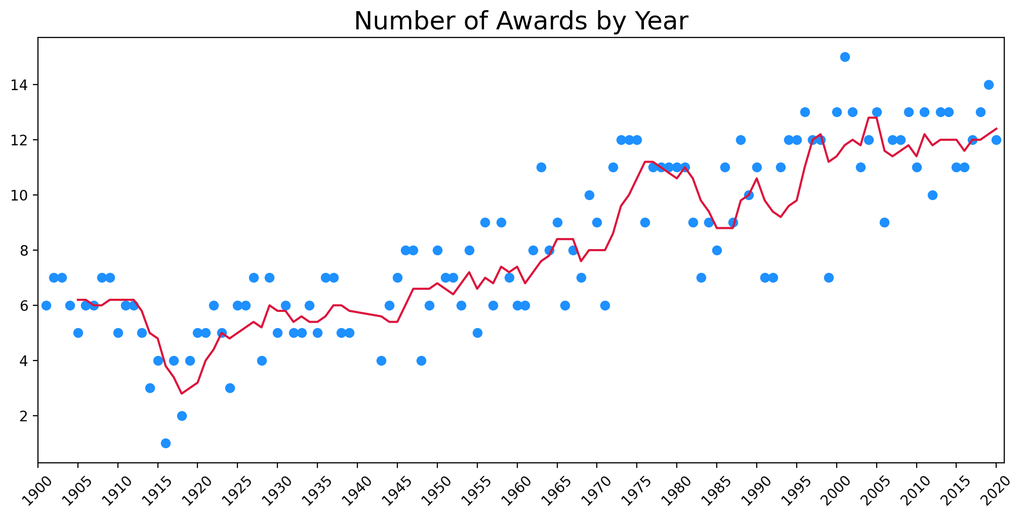

```python
plt.figure(figsize=(10, 5), layout='constrained', dpi=200)
plt.title('Number of Awards by Year', fontsize=18)
plt.scatter(x=years.index, y=years['by_year'], color='dodgerblue')
plt.plot(years['rolling'], color='crimson')

plt.xlim(years.index[0] -1, years.index[-1] +1)
plt.xticks(np.arange(1900, 2021, 5), rotation=45)
plt.show()
```

# Are More Prizes Shared Than Before?

**Challenge**: Investigate if more prizes are shared than before.

- Calculate the average prize share of the winners on a year by year basis.
- Calculate the 5 year rolling average of the percentage share.
- Copy-paste the cell from the chart you created above.
- Modify the code to add a secondary axis to your Matplotlib chart.
- Plot the rolling average of the prize share on this chart.
- See if you can invert the secondary y-axis to make the relationship even more clear.

```python
prize_share = df_data.groupby(by='year').agg({'prize_share': pd.Series.mean})
rol_ps = prize_share['prize_share'].rolling(5).mean()

# Create the DataFrame with the aligned rolling mean
prize_share_combined = pd.DataFrame({
    'prize_share': prize_share['prize_share'],  # Extract the series from the DataFrame
    'rolling': rol_ps
}, index=prize_share.index)

prize_share_combined.head(10)
```

| year | prize_share | rolling |
| --- | --- | --- |
| 1901 | 0.83 | NaN |
| 1902 | 0.71 | NaN |
| 1903 | 0.71 | NaN |
| 1904 | 0.83 | NaN |
| 1905 | 1.00 | 0.82 |
| 1906 | 0.83 | 0.82 |
| 1907 | 0.83 | 0.84 |
| 1908 | 0.71 | 0.84 |
| 1909 | 0.71 | 0.82 |
| 1910 | 1.00 | 0.82 |

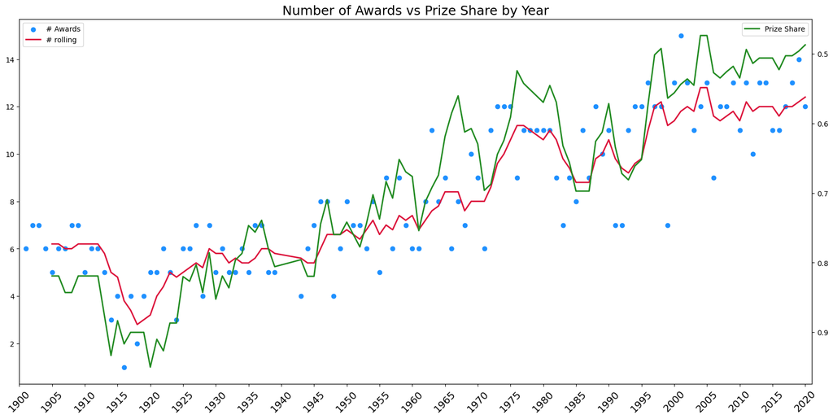

```python
plt.figure(figsize=(16, 8), layout='constrained')
plt.title('Number of Awards vs Prize Share by Year', fontsize=18)

plt.xticks(fontsize=14, rotation=45)

ax1 = plt.gca()
ax2 = ax1.twinx()

ax1.scatter(years.index, years['by_year'], color='dodgerblue', label='# Awards')
ax1.plot(years['rolling'], color='crimson', linewidth=2, label='# rolling')
ax1.set_xlim((years.index[0] -1, years.index[-1] +1))
ax1.legend(loc='upper left')

ax2.plot(prize_share_combined['rolling'], color='forestgreen',
        linewidth=2, label='Prize Share')

ax2.invert_yaxis()
ax2.legend(loc='upper right')

plt.xticks(np.arange(1900, 2021, 5), rotation=45)
plt.show()
```

# The Countries with the Most Nobel Prizes

**Challenge**:

```python
top20_countries = df_data.groupby(by='birth_country_current').size().sort_values().tail(20)
```

```python
fig = px.bar(
    top20_countries.tail(10), x=top20_countries.tail(10).values,
    y=top20_countries.tail(10).index, orientation='h',
    color=top20_countries.tail(10).values)

fig.update(layout_coloraxis_showscale=False)
fig.show()
```

[interactive chart not shown]

```python
print(top20_countries)
```

```
birth_country_current
India                         9
Hungary                       9
South Africa                  9
Australia                    10
Denmark                      12
China                        12
Norway                       12
Austria                      18
Netherlands                  18
Italy                        19
Switzerland                  19
Canada                       20
Russia                       26
Poland                       27
Japan                        27
Sweden                       29
France                       57
Germany                      84
United Kingdom              105
United States of America    281
dtype: int64
```

# Use a Choropleth Map to Show the Number of Prizes Won by Country

Hint: You'll need to use a 3 letter country code for each country.

```python
by_iso = df_data.groupby(by='ISO').size().sort_values(ascending=False)
fig = px.choropleth(
    by_iso, locations=by_iso.index, color=by_iso.values,
    color_continuous_scale=px.colors.sequential.matter)

fig.show()
```

[interactive chart not shown]

# In Which Categories are the Different Countries Winning Prizes?

- In which category are Germany and Japan the weakest compared to the United States?
- In which category does Germany have more prizes than the UK?
- In which categories does France have more prizes than Germany?
- Which category makes up most of Australia's nobel prizes?
- Which category makes up half of the prizes in the Netherlands?
- Does the United States have more prizes in Economics than all of France? What about in Physics or Medicine?

The hard part is preparing the data for this chart!

```python
birth_prize = df_data.groupby(by=['birth_country_current', 'category']).size().unstack(fill_value=0)
# Add a total column that sums across the category columns
birth_prize['total_prize'] = birth_prize.sum(axis=1)
birth_prize = birth_prize.sort_values(by='total_prize')
```

```python
fig = px.bar(birth_prize.tail(10), x=birth_prize.tail(10).columns[:-1], y=birth_prize.tail(10).index, orientation='h',
            title="Number of Prizes Awarded per Country split by Category")

fig.update_layout(
    xaxis_title="Nobel Prizes Awarded",
    yaxis_title="Country",
    legend_title_text="Category",
)
fig.show()
```

[interactive chart not shown]

```python
birth_prize.loc[['United States of America', 'Japan', 'Germany']]
```

| category birth_country_current | Chemistry | Economics | Literature | Medicine | Peace | Physics | total_prize |
| --- | --- | --- | --- | --- | --- | --- | --- |
| United States of America | 55 | 49 | 10 | 78 | 19 | 70 | 281 |
| Japan | 7 | 0 | 3 | 5 | 1 | 11 | 27 |
| Germany | 26 | 1 | 8 | 18 | 5 | 26 | 84 |

```python
birth_prize.loc[['Germany', 'United Kingdom']]
```

| category birth_country_current | Chemistry | Economics | Literature | Medicine | Peace | Physics | total_prize |
| --- | --- | --- | --- | --- | --- | --- | --- |
| Germany | 26 | 1 | 8 | 18 | 5 | 26 | 84 |
| United Kingdom | 27 | 8 | 7 | 28 | 11 | 24 | 105 |

```python
birth_prize.loc[['Germany', 'France']]
```

| category birth_country_current | Chemistry | Economics | Literature | Medicine | Peace | Physics | total_prize |
| --- | --- | --- | --- | --- | --- | --- | --- |
| Germany | 26 | 1 | 8 | 18 | 5 | 26 | 84 |
| France | 10 | 4 | 11 | 12 | 10 | 10 | 57 |

```python
birth_prize.loc[['Australia']]
```

| category birth_country_current | Chemistry | Economics | Literature | Medicine | Peace | Physics | total_prize |
| --- | --- | --- | --- | --- | --- | --- | --- |
| Australia | 1 | 0 | 0 | 7 | 0 | 2 | 10 |

```python
birth_prize.loc[['Netherlands']]
```

| category birth_country_current | Chemistry | Economics | Literature | Medicine | Peace | Physics | total_prize |
| --- | --- | --- | --- | --- | --- | --- | --- |
| Netherlands | 4 | 2 | 0 | 2 | 1 | 9 | 18 |

```python
birth_prize.loc[['United States of America', 'France']]
```

| category birth_country_current | Chemistry | Economics | Literature | Medicine | Peace | Physics | total_prize |
| --- | --- | --- | --- | --- | --- | --- | --- |
| United States of America | 55 | 49 | 10 | 78 | 19 | 70 | 281 |
| France | 10 | 4 | 11 | 12 | 10 | 10 | 57 |

### Number of Prizes Won by Each Country Over Time

- When did the United States eclipse every other country in terms of the number of prizes won?
- Which country or countries were leading previously?
- Calculate the cumulative number of prizes won by each country in every year. Again, use the `birth_country_current` of the winner to calculate this.
- Create a [plotly line chart](https://plotly.com/python/line-charts/) where each country is a coloured line.

```python
df_data.head()
```

|  | year | category | prize | motivation | prize_share | laureate_type | full_name | birth_date | birth_city | birth_country | birth_country_current | sex | organization_name | organization_city | organization_country | ISO |
| --- | --- | --- | --- | --- | --- | --- | --- | --- | --- | --- | --- | --- | --- | --- | --- | --- |
| 0 | 1901 | Chemistry | The Nobel Prize in Chemistry 1901 | "in recognition of the extraordinary services ... | 1.00 | Individual | Jacobus Henricus van 't Hoff | 1852-08-30 | Rotterdam | Netherlands | Netherlands | Male | Berlin University | Berlin | Germany | NLD |
| 1 | 1901 | Literature | The Nobel Prize in Literature 1901 | "in special recognition of his poetic composit... | 1.00 | Individual | Sully Prudhomme | 1839-03-16 | Paris | France | France | Male | NaN | NaN | NaN | FRA |
| 2 | 1901 | Medicine | The Nobel Prize in Physiology or Medicine 1901 | "for his work on serum therapy, especially its... | 1.00 | Individual | Emil Adolf von Behring | 1854-03-15 | Hansdorf (Lawice) | Prussia (Poland) | Poland | Male | Marburg University | Marburg | Germany | POL |
| 3 | 1901 | Peace | The Nobel Peace Prize 1901 | NaN | 0.50 | Individual | Frédéric Passy | 1822-05-20 | Paris | France | France | Male | NaN | NaN | NaN | FRA |
| 4 | 1901 | Peace | The Nobel Peace Prize 1901 | NaN | 0.50 | Individual | Jean Henry Dunant | 1828-05-08 | Geneva | Switzerland | Switzerland | Male | NaN | NaN | NaN | CHE |

```python
county_year = df_data.groupby(by=['year', 'birth_country_current']).size().unstack(fill_value=0)
# Make it cumulative by year
county_year_cumsum = county_year.cumsum()

county_year_cumsum.tail()
```

| birth_country_current year | Algeria | Argentina | Australia | Austria | Azerbaijan | Bangladesh | Belarus | Belgium | Bosnia and Herzegovina | Brazil | ... | Taiwan | Trinidad | Turkey | Ukraine | United Kingdom | United States of America | Venezuela | Vietnam | Yemen | Zimbabwe |
| --- | --- | --- | --- | --- | --- | --- | --- | --- | --- | --- | --- | --- | --- | --- | --- | --- | --- | --- | --- | --- | --- |
| 2016 | 2 | 4 | 10 | 17 | 1 | 1 | 4 | 9 | 2 | 1 | ... | 1 | 1 | 3 | 5 | 99 | 259 | 1 | 1 | 1 | 1 |
| 2017 | 2 | 4 | 10 | 17 | 1 | 1 | 4 | 9 | 2 | 1 | ... | 1 | 1 | 3 | 5 | 100 | 265 | 1 | 1 | 1 | 1 |
| 2018 | 2 | 4 | 10 | 17 | 1 | 1 | 4 | 9 | 2 | 1 | ... | 1 | 1 | 3 | 5 | 101 | 271 | 1 | 1 | 1 | 1 |
| 2019 | 2 | 4 | 10 | 18 | 1 | 1 | 4 | 9 | 2 | 1 | ... | 1 | 1 | 3 | 5 | 103 | 274 | 1 | 1 | 1 | 1 |
| 2020 | 2 | 4 | 10 | 18 | 1 | 1 | 4 | 9 | 2 | 1 | ... | 1 | 1 | 3 | 5 | 105 | 281 | 1 | 1 | 1 | 1 |

5 rows × 79 columns

```python
l_chart = px.line(county_year_cumsum)

l_chart.update_layout(
    xaxis_title='Year', yaxis_title='Number of Prizes')

l_chart.show()
```

[interactive chart not shown]

# What are the Top Research Organisations?

- Which organisations make up the top 20?
- How many Nobel prize winners are affiliated with the University of Chicago and Harvard University?

```python
by_org = df_data.groupby(by='organization_name').size()
by_org = by_org.sort_values()
```

```python
fig = px.bar(
    by_org.tail(20), x=by_org.tail(20).values, y=by_org.tail(20).index,
    orientation='h', color=by_org.tail(20).values,
    color_continuous_scale=px.colors.sequential.Aggrnyl)

fig.update(layout_coloraxis_showscale=False)
fig.update_layout(xaxis_title='Number of Prizes', yaxis_title='Institution')
fig.show()
```

[interactive chart not shown]

# Which Cities Make the Most Discoveries?

Where do major discoveries take place?

**Challenge**:

- Create another plotly bar chart graphing the top 20 organisation cities of the research institutions associated with a Nobel laureate.
- Where is the number one hotspot for discoveries in the world?
- Which city in Europe has had the most discoveries?

```python
by_city = df_data.groupby(by='organization_city').size()
by_city = by_city.sort_values(ascending=False)
print(by_city.head())
```

```
organization_city
Cambridge, MA    50
New York, NY     45
Cambridge        31
London           27
Paris            25
dtype: int64
```

```python
fig = px.bar(by_city.head(20), x=by_city.head(20).index, y=by_city.head(20),
            title="Top 20 Citys for Noble Prizes", color=by_city.head(20))

fig.update(layout_coloraxis_showscale=False)
fig.update_layout(yaxis_title="Nobel Prizes Awarded", xaxis_title="City Name")
fig.show()
```

[interactive chart not shown]

# Where are Nobel Laureates Born? Chart the Laureate Birth Cities

**Challenge**:

- Create a plotly bar chart graphing the top 20 birth cities of Nobel laureates.
- Use a named colour scale called `Plasma` for the chart.
- What percentage of the United States prizes came from Nobel laureates born in New York?
- How many Nobel laureates were born in London, Paris and Vienna?
- Out of the top 5 cities, how many are in the United States?

```python
birth_city = df_data.groupby(by='birth_city').size()
birth_city = birth_city.sort_values(ascending=False).head(20)
print(birth_city.head())
```

```
birth_city
New York, NY    53
Paris           26
London          19
Vienna          14
Chicago, IL     12
dtype: int64
```

```python
fig = px.bar(birth_city, x=birth_city.index, y=birth_city, color=birth_city,
            title="Top 20 Birth Citys for Noble Prizes",
            color_continuous_scale=px.colors.sequential.Plasma)

fig.update(layout_coloraxis_showscale=False)
fig.update_layout(yaxis_title="Nobel Prizes Awarded", xaxis_title="Birth City Name")
fig.show()
```

[interactive chart not shown]

```python
united_states = top20_countries.loc['United States of America']
new_york = birth_city.loc['New York, NY']
print(f'The percentage of New Yorkers Lauriets of U.S.A is {(new_york/united_states):.0%}')
```

```
The percentage of New Yorkers Lauriets of U.S.A is 19%
```

# Plotly Sunburst Chart: Combine Country, City, and Organisation

**Challenge**:

- Create a DataFrame that groups the number of prizes by organisation.
- Then use the [plotly documentation to create a sunburst chart](https://plotly.com/python/sunburst-charts/)
- Click around in your chart, what do you notice about Germany and France?

```python
country_city_org = df_data.groupby(by=['organization_country',
                                        'organization_city',
                                        'organization_name'], as_index=False).agg({'prize': pd.Series.count})

country_city_org = country_city_org.sort_values('prize', ascending=False)
```

```python
burst = px.sunburst(country_city_org,
                    path=['organization_country', 'organization_city', 'organization_name'],
                    values='prize')

burst.update_layout(coloraxis_showscale=False)
burst.show()
```

[interactive chart not shown]

# Patterns in the Laureate Age at the Time of the Award

How Old Are the Laureates When the Win the Prize?

**Challenge**: Calculate the age of the laureate in the year of the ceremony and add this as a column called `winning_age` to the `df_data` DataFrame. Hint: you can use [this](https://pandas.pydata.org/pandas-docs/stable/reference/api/pandas.Series.dt.html) to help you.

```python
df_data['winning_age'] = (df_data['year'] - df_data['birth_date'].dt.year).astype('Int64')
df_data.head()
```

|  | year | category | prize | motivation | prize_share | laureate_type | full_name | birth_date | birth_city | birth_country | birth_country_current | sex | organization_name | organization_city | organization_country | ISO | winning_age |
| --- | --- | --- | --- | --- | --- | --- | --- | --- | --- | --- | --- | --- | --- | --- | --- | --- | --- |
| 0 | 1901 | Chemistry | The Nobel Prize in Chemistry 1901 | "in recognition of the extraordinary services ... | 1.00 | Individual | Jacobus Henricus van 't Hoff | 1852-08-30 | Rotterdam | Netherlands | Netherlands | Male | Berlin University | Berlin | Germany | NLD | 49 |
| 1 | 1901 | Literature | The Nobel Prize in Literature 1901 | "in special recognition of his poetic composit... | 1.00 | Individual | Sully Prudhomme | 1839-03-16 | Paris | France | France | Male | NaN | NaN | NaN | FRA | 62 |
| 2 | 1901 | Medicine | The Nobel Prize in Physiology or Medicine 1901 | "for his work on serum therapy, especially its... | 1.00 | Individual | Emil Adolf von Behring | 1854-03-15 | Hansdorf (Lawice) | Prussia (Poland) | Poland | Male | Marburg University | Marburg | Germany | POL | 47 |
| 3 | 1901 | Peace | The Nobel Peace Prize 1901 | NaN | 0.50 | Individual | Frédéric Passy | 1822-05-20 | Paris | France | France | Male | NaN | NaN | NaN | FRA | 79 |
| 4 | 1901 | Peace | The Nobel Peace Prize 1901 | NaN | 0.50 | Individual | Jean Henry Dunant | 1828-05-08 | Geneva | Switzerland | Switzerland | Male | NaN | NaN | NaN | CHE | 73 |

### Who were the oldest and youngest winners?

**Challenge**:

- What are the names of the youngest and oldest Nobel laureate?
- What did they win the prize for?
- What is the average age of a winner?
- 75% of laureates are younger than what age when they receive the prize?
- Use Seaborn to [create histogram](https://seaborn.pydata.org/generated/seaborn.histplot.html) to visualise the distribution of laureate age at the time of winning. Experiment with the number of `bins` to see how the visualisation changes.

```python
by_age = df_data.dropna(subset=['winning_age']).sort_values(by='winning_age')
by_age
```

|  | year | category | prize | motivation | prize_share | laureate_type | full_name | birth_date | birth_city | birth_country | birth_country_current | sex | organization_name | organization_city | organization_country | ISO | winning_age |
| --- | --- | --- | --- | --- | --- | --- | --- | --- | --- | --- | --- | --- | --- | --- | --- | --- | --- |
| 885 | 2014 | Peace | The Nobel Peace Prize 2014 | "for their struggle against the suppression of... | 0.50 | Individual | Malala Yousafzai | 1997-07-12 | Mingora | Pakistan | Pakistan | Female | NaN | NaN | NaN | PAK | 17 |
| 85 | 1915 | Physics | The Nobel Prize in Physics 1915 | "for their services in the analysis of crystal... | 0.50 | Individual | William Lawrence Bragg | 1890-03-31 | Adelaide | Australia | Australia | Male | Victoria University | Manchester | United Kingdom | AUS | 25 |
| 932 | 2018 | Peace | The Nobel Peace Prize 2018 | “for their efforts to end the use of sexual vi... | 0.50 | Individual | Nadia Murad | 1993-07-02 | Kojo | Iraq | Iraq | Female | NaN | NaN | NaN | IRQ | 25 |
| 166 | 1932 | Physics | The Nobel Prize in Physics 1932 | "for the creation of quantum mechanics, the ap... | 1.00 | Individual | Werner Karl Heisenberg | 1901-12-05 | Würzburg | Germany | Germany | Male | Leipzig University | Leipzig | Germany | DEU | 31 |
| 188 | 1936 | Physics | The Nobel Prize in Physics 1936 | "for his discovery of the positron" | 0.50 | Individual | Carl David Anderson | 1905-09-03 | New York, NY | United States of America | United States of America | Male | California Institute of Technology (Caltech) | Pasadena, CA | United States of America | USA | 31 |
| ... | ... | ... | ... | ... | ... | ... | ... | ... | ... | ... | ... | ... | ... | ... | ... | ... | ... |
| 856 | 2012 | Economics | The Sveriges Riksbank Prize in Economic Scienc... | "for the theory of stable allocations and the ... | 0.50 | Individual | Lloyd S. Shapley | 1923-06-02 | Cambridge, MA | United States of America | United States of America | Male | University of California | Los Angeles, CA | United States of America | USA | 89 |
| 961 | 2020 | Physics | The Nobel Prize in Physics 2020 | “for the discovery that black hole formation i... | 0.50 | Individual | Roger Penrose | 1931-08-08 | Colchester | United Kingdom | United Kingdom | Male | University of Oxford | Oxford | United Kingdom | GBR | 89 |
| 794 | 2007 | Economics | The Sveriges Riksbank Prize in Economic Scienc... | "for having laid the foundations of mechanism ... | 0.33 | Individual | Leonid Hurwicz | 1917-08-21 | Moscow | Russia | Russia | Male | University of Minnesota | Minneapolis, MN | United States of America | RUS | 90 |
| 933 | 2018 | Physics | The Nobel Prize in Physics 2018 | “for the optical tweezers and their applicatio... | 0.50 | Individual | Arthur Ashkin | 1922-09-02 | New York, NY | United States of America | United States of America | Male | Bell Laboratories | Holmdel, NJ | United States of America | USA | 96 |
| 937 | 2019 | Chemistry | The Nobel Prize in Chemistry 2019 | “for the development of lithium-ion batteries” | 0.33 | Individual | John Goodenough | 1922-07-25 | Jena | Germany | Germany | Male | University of Texas | Austin TX | United States of America | DEU | 97 |

934 rows × 17 columns

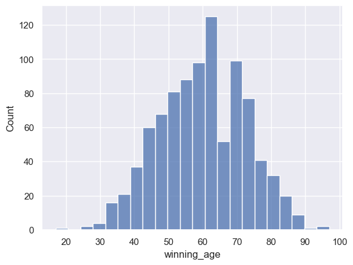

```python
sns.set_theme(style="darkgrid")
sns.histplot(df_data, x='winning_age')

plt.show()
```

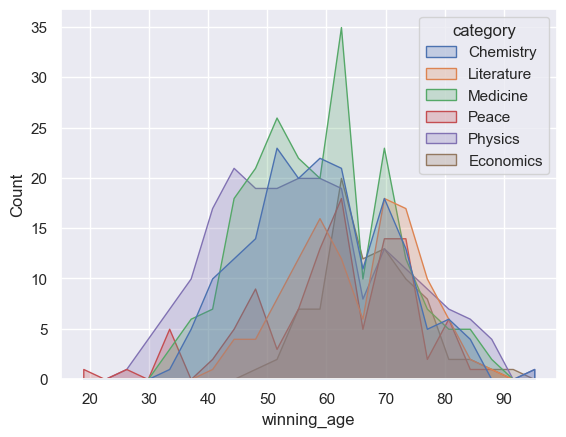

```python
sns.set_theme(style="darkgrid")
sns.histplot(df_data, x='winning_age', hue='category', element='poly')

plt.show()
```

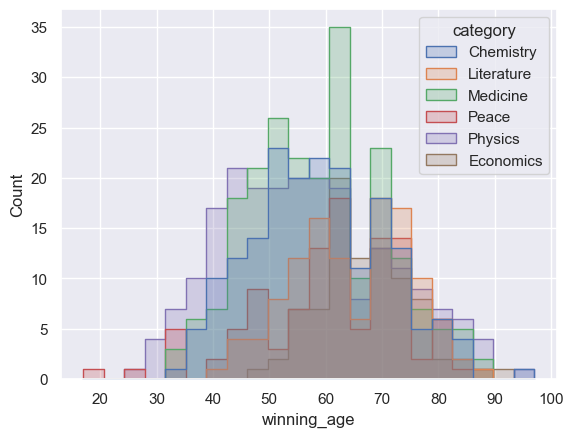

```python
sns.set_theme(style="darkgrid")
sns.histplot(df_data, x='winning_age', hue='category', element='step')

plt.show()
```

### Descriptive Statistics for the Laureate Age at Time of Award

- Calculate the descriptive statistics for the age at the time of the award.
- Then visualise the distribution in the form of a histogram using [Seaborn's .histplot() function](https://seaborn.pydata.org/generated/seaborn.histplot.html).
- Experiment with the `bin` size. Try 10, 20, 30, and 50.

```python
df_data.describe()
```

|  | year | prize_share | birth_date | winning_age |
| --- | --- | --- | --- | --- |
| count | 962.00 | 962.00 | 934 | 934.00 |
| mean | 1,971.82 | 0.63 | 1912-03-28 22:50:37.259100672 | 59.95 |
| min | 1,901.00 | 0.25 | 1817-11-30 00:00:00 | 17.00 |
| 25% | 1,948.00 | 0.33 | 1892-04-06 00:00:00 | 51.00 |
| 50% | 1,977.00 | 0.50 | 1917-10-30 12:00:00 | 60.00 |
| 75% | 2,001.00 | 1.00 | 1937-04-24 18:00:00 | 69.00 |
| max | 2,020.00 | 1.00 | 1997-07-12 00:00:00 | 97.00 |
| std | 33.81 | 0.29 | NaN | 12.62 |

### Age at Time of Award throughout History

Are Nobel laureates being nominated later in life than before? Have the ages of laureates at the time of the award increased or decreased over time?

**Challenge**

- Use Seaborn to [create a .regplot](https://seaborn.pydata.org/generated/seaborn.regplot.html?highlight=regplot#seaborn.regplot) with a trendline.
- Set the `lowess` parameter to `True` to show a moving average of the linear fit.
- According to the best fit line, how old were Nobel laureates in the years 1900-1940 when they were awarded the prize?
- According to the best fit line, what age would it predict for a Nobel laureate in 2020?

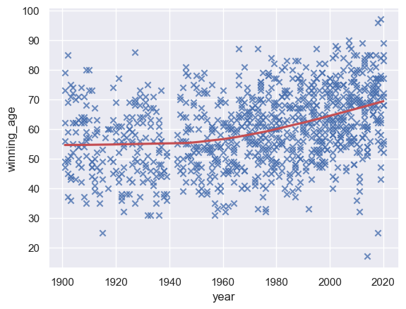

```python
sns.regplot(
    df_data, x='year', y='winning_age', lowess=True,
    marker="x", line_kws=dict(color="r"))

plt.show()
```

### Winning Age Across the Nobel Prize Categories

How does the age of laureates vary by category?

- Use Seaborn's [`.boxplot()`](https://seaborn.pydata.org/generated/seaborn.boxplot.html?highlight=boxplot#seaborn.boxplot) to show how the mean, quartiles, max, and minimum values vary across categories. Which category has the longest "whiskers"?
- In which prize category are the average winners the oldest?
- In which prize category are the average winners the youngest?

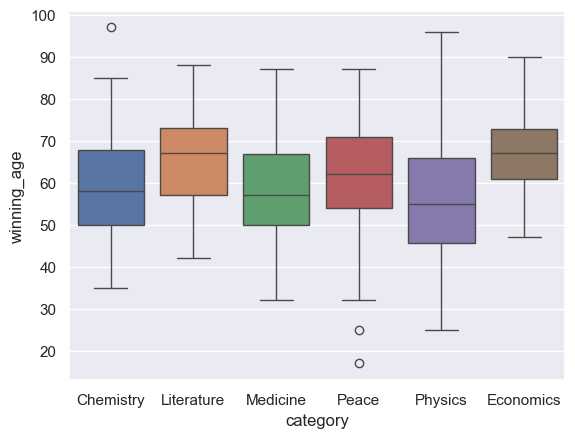

```python
sns.boxplot(data=df_data, x="category", y='winning_age', hue="category")

plt.show()
```

```python
fig = px.box(df_data, x="category", y="winning_age", color="category")
fig.update_traces(quartilemethod="exclusive") # or "inclusive", or "linear" by default
fig.show()
```

[interactive chart not shown]

**Challenge**

- Now use Seaborn's [`.lmplot()`](https://seaborn.pydata.org/generated/seaborn.lmplot.html?highlight=lmplot#seaborn.lmplot) and the `row` parameter to create 6 separate charts for each prize category. Again set `lowess` to `True`.
- What are the winning age trends in each category?
- Which category has the age trending up and which category has the age trending down?
- Is this `.lmplot()` telling a different story from the `.boxplot()`?
- Create another chart with Seaborn. This time use `.lmplot()` to put all 6 categories on the same chart using the `hue` parameter.

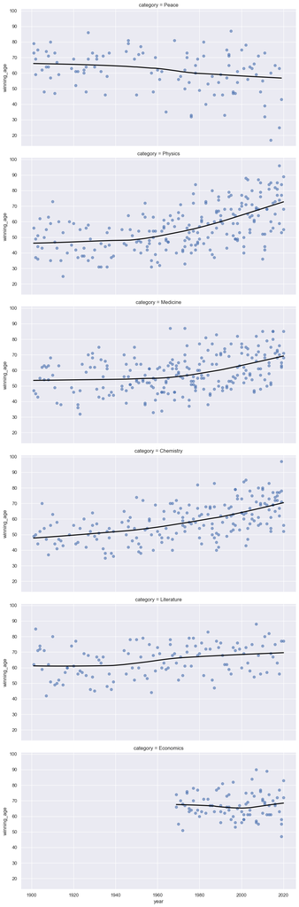

```python
sns.lmplot(
    data=by_age, x='year', y='winning_age', row = 'category', lowess=True,
    aspect=2, scatter_kws = {'alpha': 0.6}, line_kws = {'color': 'black'})

plt.show()
```

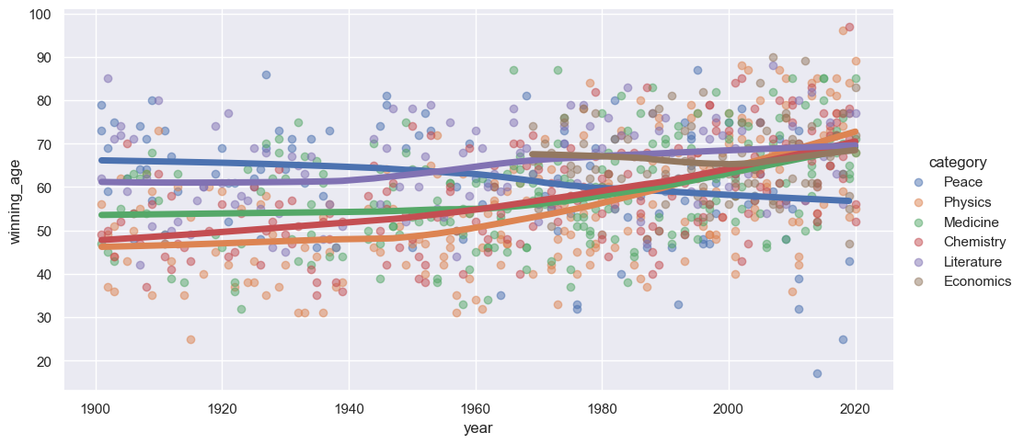

```python
sns.lmplot(
    data=by_age, x='year', y='winning_age', hue='category', lowess=True, aspect=2,
    scatter_kws={'alpha': 0.5}, line_kws={'linewidth': 5})

plt.show()
```